# Le qubit

Le qubit est un concept d'informatique quantique qui repose sur des particules comme les ions ou les photons, qui sont des particules de lumière. Il se distingue par sa faculté à être simultanément dans l'état 0 et l'état 1 grâce à une mécanique probabiliste.

# Représentation

Mathématiquement, un qubit est noté de la [manière suivante :](https://learn.microsoft.com/fr-fr/azure/quantum/concepts-the-qubit#representing-a-qubit)

$$ |\psi\rangle = \alpha|0\rangle + \beta|1\rangle $$

$\alpha $ et $\beta$ sont les amplitudes du qubit.

Avec $\psi\rangle$ définissant l'état du qubit reposant sur deux valeurs $\alpha$ et $\beta$ définissant les amplitudes $0\rangle$ et réciproquement $1\rangle$ sur le qubit.

Autrement, il peut être représenté sous forme matricielle :

$$ |\psi\rangle = \begin{pmatrix} \alpha \\ \beta \end{pmatrix}. $$

En programmation, cela donne :

```python
import numpy as np

alpha = 1
beta  = 0

qubit = np.array([alpha, beta])
```

# Les probabilités

Les amplitudes sont rattachées à des probabilités : celle d'obtenir 0 ou 1, notée $P(0)$, et réciproquement $P(1)$ lors de l'observation.

On définit la probabilité d'obtenir 0 lors d'une observation :

$$ P(0) = |\alpha|^2 $$

et d'obtenir 1 :

$$ P(1) = |\beta|^2 $$

Les valeurs de alpha et beta (les amplitudes) respectent la règle de [Max Born](https://fr.wikipedia.org/wiki/Th%C3%A9orie_des_probabilit%C3%A9s#Historique) suivante :

$$ |\alpha|^2 + |\beta|^2 = 1 $$

On définit les fonctions de récupération des probabilités de la manière suivante :

```python
# Définition de la fonction de la probabilité d'avoir 0 (P(0)) sur un qubit

def P0(qubit):
    return abs(qubit[0])**2 * 100


# Définition de la fonction de la probabilité d'avoir 1 (P(1)) sur un qubit

def P1(qubit):
    return abs(qubit[1])**2 * 100
```

# Le Qubit et ses deux États majeurs : |0⟩ et |1⟩

Pourquoi définir alpha à 1 et beta à 0 ?

Ces valeurs sont assignées de cette manière pour correspondre à l'état fondamental dans l'espace de Hilbert, représenté comme ceci :

$$ |0\rangle = \begin{pmatrix} 1 \\ 0 \end{pmatrix} $$

Cet état correspond à une probabilité d'observer la valeur 0 égale à 100 %.

Le vecteur ci-dessus illustre que la probabilité d'obtenir 0 est de 100 %, tandis que la probabilité d'obtenir 1 est de 0 %.

Réciproquement, on a l'état excité :

$$ |1\rangle = \begin{pmatrix} 0 \\ 1 \end{pmatrix} $$

L'excitation, en physique, correspond au moment où un qubit parvient à acquérir une énergie supérieure à son état fondamental |0⟩.

En somme, plus la probabilité P(1) est élevée, plus l'excitation du qubit est grande. À l'inverse, plus P(0) est haute, plus le qubit correspond à son état de base.

À noter que cette graduation est notable uniquement par estimation ; lorsqu'on observe un qubit, sa valeur est strictement égale à 0 ou 1.

Visuellement, cela pourrait être représenté sous forme de sphère de Bloch (généré par mon code et inspiré de [cette simulation](https://www.utc.fr/~wschon/sr06/demonstrateur-algorithmes-quantiques-master/website/_site/qubitAnimation.html))

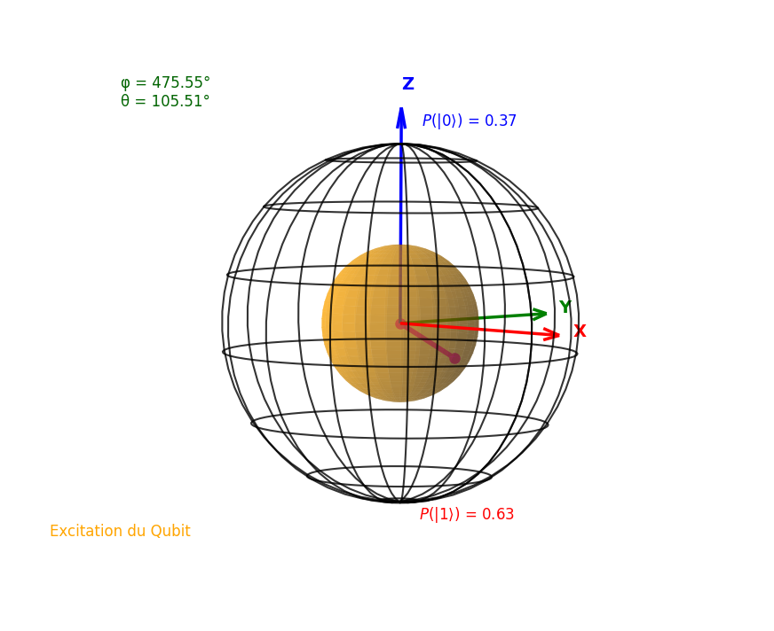

L'orientation d'un qubit est régie par trois axes : X, Y et Z, comme illustré sur le schéma ci-dessus. Cependant, elle est principalement déterminée par phi et theta, qui définissent la direction du qubit en degrés dans l'espace.

NB : Dans la section suivante, nous expliquerons comment calculer ces valeurs.

La sphère squelettique représente la taille maximale que peut atteindre un qubit en état d'excitation, tandis que la sphère jaune correspond à la graduation estimée de l'excitation du qubit, soit sa taille actuelle au moment de la mesure.

# Les angles dans les qubits

D'après le lien précédent qui définit [l'équivalence](https://en.wikipedia.org/wiki/Qubit#Bloch_sphere_representation) entre alpha, bêta et les angles phi et theta, on peut déduire que :

$$ \alpha = \cos\!\Bigl(\frac{\theta}{2}\Bigr) \quad\Longrightarrow\quad \theta = 2\,\arccos\!\bigl(\alpha\bigr) $$

$$ \beta = e^{i\phi}\,\sin\!\Bigl(\frac{\theta}{2}\Bigr) \quad\Longrightarrow\quad e^{i\phi} = \frac{\beta}{\sin(\theta/2)} \quad\Longrightarrow\quad \phi = \arg\!\Bigl(\tfrac{\beta}{\sin(\theta/2)}\Bigr) = \arg(\beta) $$

On définit leurs équivalents en code :

```python
import cmath
import math

# Définition de la fonction pour le calcul de theta

def theta(qubit):

    # On applique la formule de base de theta en radian
    rad = 2 * cmath.acos(qubit[0]).real
    return rad

def theta_degre(qubit):

    # On passe en degrés
    return math.degrees(theta(qubit))


# Définition de la fonction pour le calcul de phi

def phi(qubit):

    # On applique la formule de base de phi en radian
    rad = np.angle(qubit[1])

    return rad


def phi_degre(qubit):

    # On passe en degrés
    return math.degrees(phi(qubit))
```

Exemple d'application :

```python
print("\nValeur des angles du qubit en état fondamental (|0>) : ")

alpha = 1
beta = 0

qubit_fondamental = np.array([alpha, beta])

print("phi :", phi_degre(qubit_fondamental))
print("theta :", theta_degre(qubit_fondamental))


print("\nValeur des angles du qubit en état excité (|1>) : ")

alpha = 0
beta = 1

qubit_excite = np.array([alpha, beta])

print("phi :", phi_degre(qubit_excite))
print("theta :", theta_degre(qubit_excite))
```

```
Valeur des angles du qubit en état fondamental (|0>) :
phi : 0.0
theta : 0.0

Valeur des angles du qubit en état excité (|1>) :
phi : 0.0
theta : 180.0
```